# Lecture 6 - Data visualization 2

2022-09-22

## Review

- Finished R markdown introduction
- R packages
- `tidyverse` package
- `ggplot2` package

## Today

- More `ggplot`!
  - Aesthetic mapping
  - Categorical and numerical variables
  - Aesthetics vs. arguments
  - Common problems
  - Multiple plots
  - Different kinds of plots

## geoms

- geom function add layers to the coordinate system created from the `ggplot()` function.
- The `geom_point()` adds a layer of a scatterplot.
- Each geom function in ggplot2 takes a mapping argument.
  - This defines how variables in your dataset are mapped to visual properties
  - the mapping argument is always paired with `aes()`
  - `displ` gets mapped to the `x`-position `aes`thetic of the points
  - `hwy` gets mapped to the `y`-position `aes`thetic of the points

## Aesthetics

- `displ` gets mapped to the x-position aesthetic of the points
- `hwy` gets mapped to the y-position aesthetic of the points

## Aesthetics

- An **aesthetic** is a visual property of the objects in your plot
- You can convey information about your data by mapping the aesthetics in your plot to the variables in your dataset.
- Aesthetics include:
  - x-position, y-position
  - size, shape, and color of your points.

## Aesthetics: Your turn

- Type `?geom_point` to see what aesthetics can be used in `geom_point`
- Plot `displ` vs `hwy`:

```r
ggplot(data = mpg) +
  geom_point(mapping = aes(x = displ, y = hwy))
```

- Now can we map the variable `class` to the color of the points to distinguish between different types of cars?

## Answer

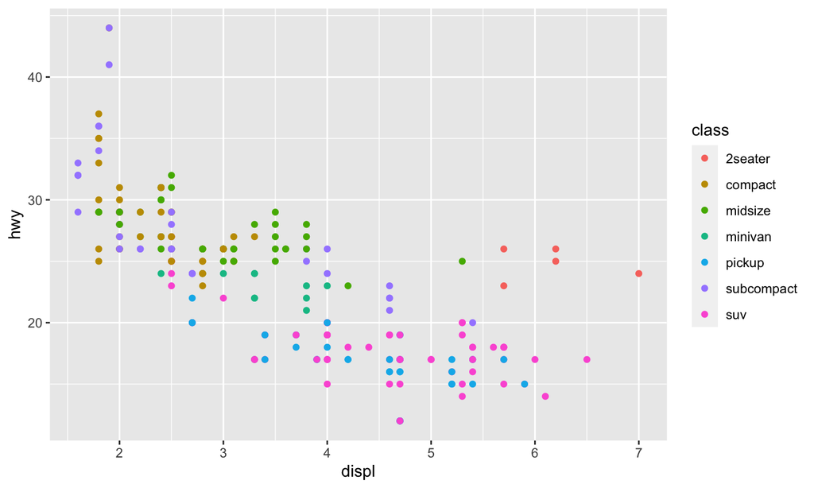

```r
ggplot(data = mpg) +
  geom_point(mapping = aes(x = displ, y = hwy,color = class))
```

## Color mappings

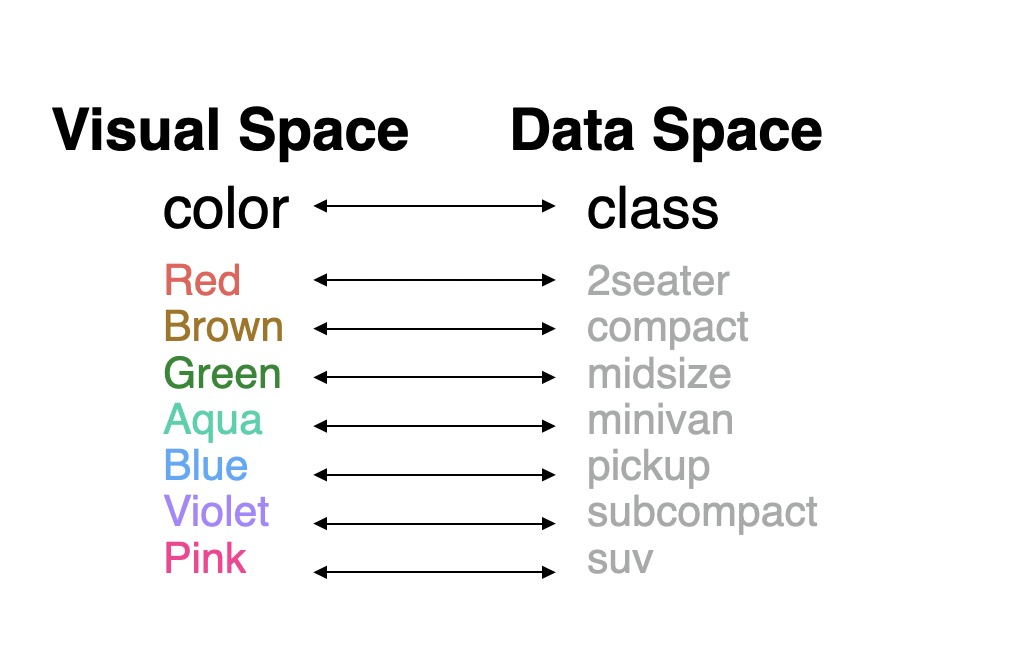

## More aesthetics

We can try other aesthetics: `size`, `alpha`, and `shape`

```
## Warning: Using size for a discrete variable is not advised.
```

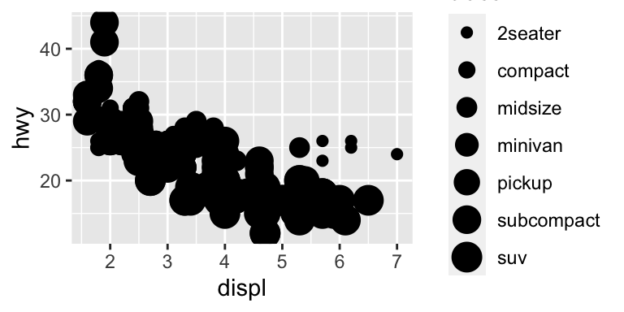

```r
ggplot(data = mpg) +
  geom_point(mapping = aes(x = displ, y = hwy, size = class))
```

Note the warning for using an unordered variable with an ordered aesthetic

## alpha

`alpha` controls opacity

```
## Warning: Using alpha for a discrete variable is not advised.
```

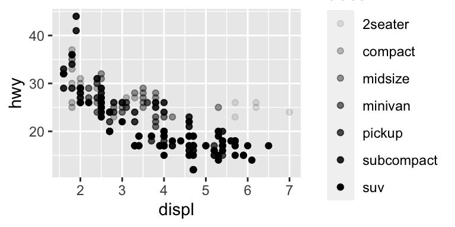

```r
ggplot(data = mpg) +
  geom_point(mapping = aes(x = displ, y = hwy, alpha = class))
```

A warning again

## shape

```
## Warning: The shape palette can deal with a maximum of 6 discrete values because
## more than 6 becomes difficult to discriminate; you have 7. Consider
## specifying shapes manually if you must have them.
```

```
## Warning: Removed 62 rows containing missing values (geom_point).
```

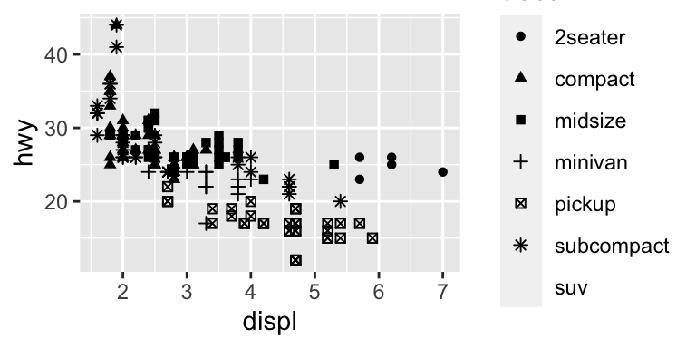

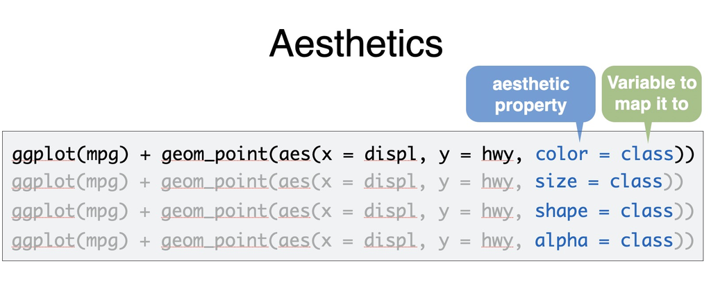

```r
ggplot(data = mpg) +
  geom_point(mapping = aes(x = displ, y = hwy, shape = class))
```

## Your turn

- What happens if you map the same (different) variable to multiple aesthetics?
- What happens if you map an aesthetic to something other than a variable name?
- Try the following code, explain what you get

```r
ggplot(data = mpg) +
  geom_point(mapping = aes(x = displ, y = hwy, color=displ < 5))
```

## Answer

What happens if you map the same (different) variable to multiple aesthetics?

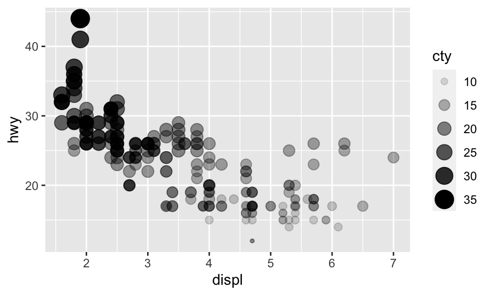

```r
ggplot(data = mpg) +
  geom_point(mapping = aes(x = displ, y = hwy, alpha=cty, size=cty))
```

## Answer

What happens if you map an aesthetic to something other than a variable name?

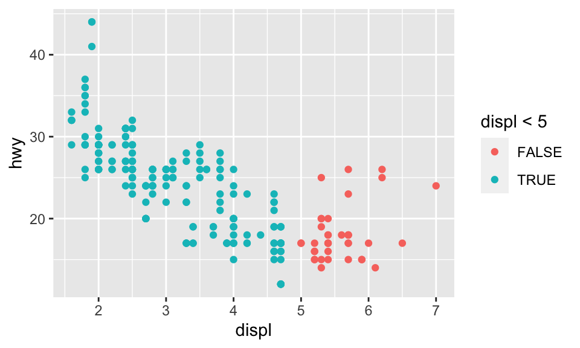

```r
ggplot(data = mpg) +
  geom_point(mapping = aes(x = displ, y = hwy, color=displ < 5))
```

## Categorical variables

- **Categorical** (qualitative) variables contain a finite number of categories or distinct groups
  - *Nominal* variables have no intrinsic ordering to its categories, e.g., gender
  - *Ordinal* variables have intrinsic ordering to its categories, e.g., education level (high school, BS, MS, PhD)

## Numerical variables

- **Numerical** (quantitative) variables are expressed in terms of numbers rather than natural language descriptions.
  - *Discrete* variables are numeric variables that have a countable number of values, e.g., age, number of students in a class
  - *Continuous* Variabels are numeric variables that have an infinite number of values between any two values, e.g., height, weight

## Your turn

- What type of variables are `displ`, `drv`, `hwy`, `class`, `year`?
- Map a numerical variable to `color`, `size`, `shape`. How do these aesthetics behave differently for categorical vs. continuous variables?

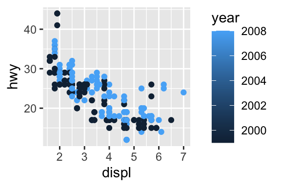

```r
ggplot(data = mpg) +
  geom_point(mapping = aes(x = displ, y = hwy, color=year ))
```

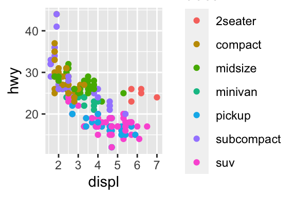

```r
ggplot(data = mpg) +
  geom_point(mapping = aes(x = displ, y = hwy, color=class ))
```

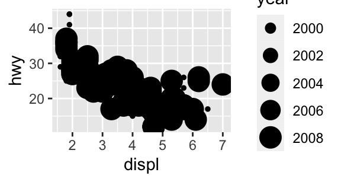

```r
ggplot(data = mpg) +
  geom_point(mapping = aes(x = displ, y = hwy, size=year ))
```

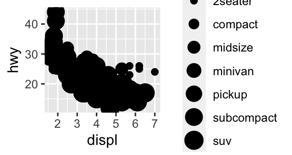

```r
ggplot(data = mpg) +
  geom_point(mapping = aes(x = displ, y = hwy, size=class ))
```

## Shape

`Error in scale_f(): ! A continuous variable can not be mapped to shape Run rlang::last_error() to see where the error occurred.`

## Aesthetics vs. arguments

You can also set the aesthetic properties of your geom manually. For example, we can make all of the points in our plot red:

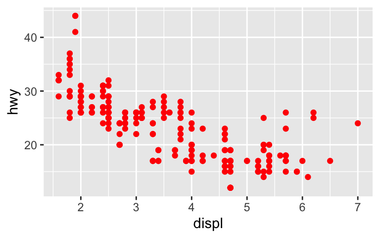

```r
ggplot(data = mpg) +
  geom_point(mapping = aes(x = displ, y = hwy), color = "red")
```

## Aesthetics vs. arguments

```r
ggplot(data = mpg) +
  geom_point(mapping = aes(x = displ, y = hwy), color = "red")
```

In the above code `red` is the argument of the `geom` function, not of the `aes()`, because we do not need to associate `color` with a variable in the `mpg` data.

To set an aesthetic manually, set the aesthetic by name as an argument of your geom function, for example:

```
- The name of a color as a character string
- The size of a point in mm
- The shape of a point as a number
```

## Your turn

Run the following code:

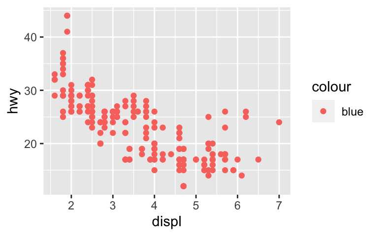

```r
ggplot(data = mpg) +
  geom_point(mapping = aes(x = displ, y = hwy, color= "blue"))
```

- Why are the points not blue?
- Can you change the code to make the points blue?

## Answer

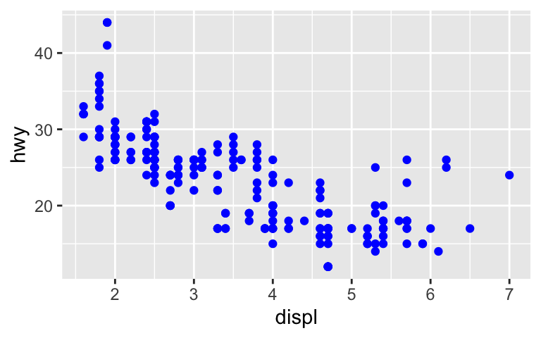

```r
ggplot(data = mpg) +
  geom_point(mapping = aes(x = displ, y = hwy), color= "blue")
```

## Common problems and some tips

R is extremely picky, and a misplaced character can make all the difference. As you start to run R code, you are likely to run into problems. Don’t worry — it happens to everyone.

- Make sure that every ( is matched with a ) and every ” is paired with another ”
- For ggplot2 graphics, `+’ has to come at the end of the line, not the start.
- If you are still stuck, try the help. You can get help about any R function by running ?function_name in the console
- Read the error message. If you cannot understand it, google it.

## Making reproducible code

1. Packages should be loaded at the top of the script, so it’s easy to see which ones the example needs.
   - This is a good time to check that you’re using the latest version of each package.
2. Spend a little bit of time ensuring that your code is easy for others to read:
   - Make sure you’ve used spaces and your variable names are concise, yet informative
   - Use comments to indicate where your problem lies
   - Do your best to remove everything that is not related to the problem. The shorter your code is, the easier it is to understand and fix.